# ggplot2

2/7/2017

## What is ggplot?

- it's a grammar for graphics
- it uses consistent building blocks to produce pictures
- it's really pretty looking, but can't do 3D or some other stuff (networks)

## What is it good at?

- Making hard plots in an easy, consistent way (more later)

## What is it bad at?

- 3D (use plot3D)
- Network plots (use igraph instead)
- Other things like extensive form games
- simple plots

## Base R

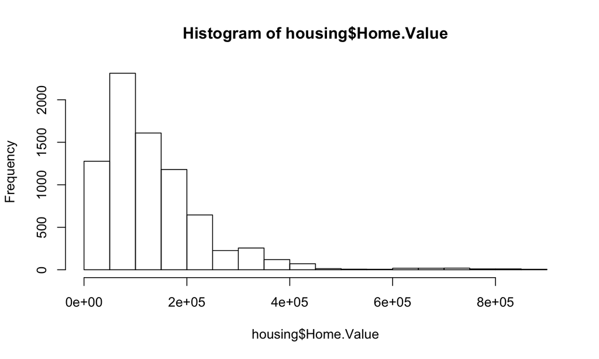

```r
hist(housing$Home.Value)
```

## ggplot

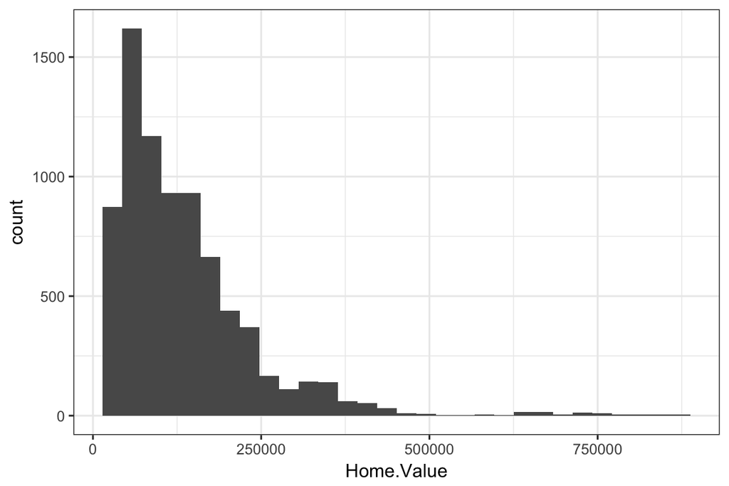

```r
ggplot(housing, aes(x = Home.Value)) + geom_histogram() + theme_bw()
```

## Harder Plot with Base R

```r
plot(Home.Value ~ Date,
     data=subset(housing, State == "MA"))
points(Home.Value ~ Date, col="red",
       data=subset(housing, State == "TX"))
legend(1975, 400000,
       c("MA", "TX"), title="State",
       col=c("black", "red"),
       pch=c(1, 1))
```

## Harder Plot with ggplot

```r
ggplot(subset(housing, State %in% c("MA", "TX")),
       aes(x = Date,
           y = Home.Value,
           color = State))+
  geom_point()
```

## Aesthetic Mapping

- In ggplot aesthetic means "something you can see" such as,
- position (i.e., on the x and y axes)
- color ("outside" color)
- fill ("inside" color)
- shape (of points)
- linetype
- size

## Geometric Object

- These are the things we put on the plot.
- points! (geom_point())
- lines! (geom_line())
- boxplots! (geom_boxplot())
- There are many others and a plot must have at least one geom (why?)

## Let's make a plot now

```r
hp2001Q1 <- subset(housing, Date == 2001.25)
ggplot(hp2001Q1,
  aes(y = Structure.Cost, x = Land.Value)) +
  geom_point() + theme_bw()
```

## Let's make a plot now

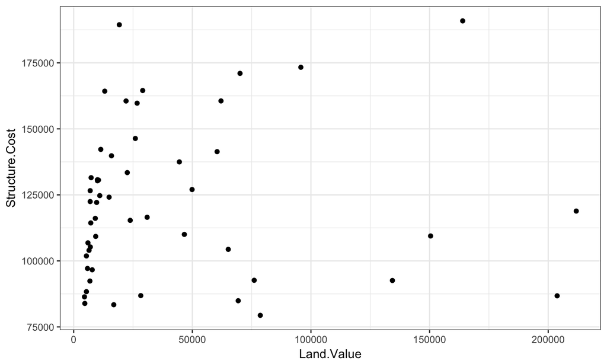

## It is easy to transform variables

```r
hp2001Q1 <- subset(housing, Date == 2001.25)
ggplot(hp2001Q1,
  aes(y = Structure.Cost, x = log(Land.Value))) +
  geom_point() + theme_bw()
```

## It is easy to transform variables

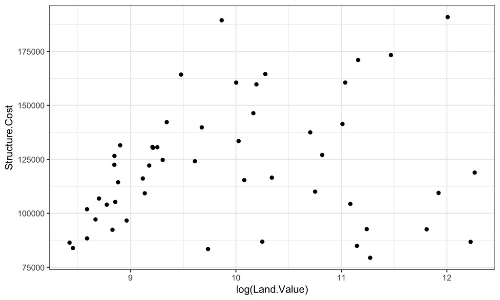

## We can do prediction lines too!

- Let's say we have a bivariate relationship and we want to do OLS on it
- We also want to plot the best fit line with some confidence intervals

## OLS with lm results

```r
ggplot(hp2001Q1, aes(x = Land.Value, y = Structure.Cost)) +
  geom_point() + stat_smooth(method = "lm", colour = "pink")
```

## OLS with lm results

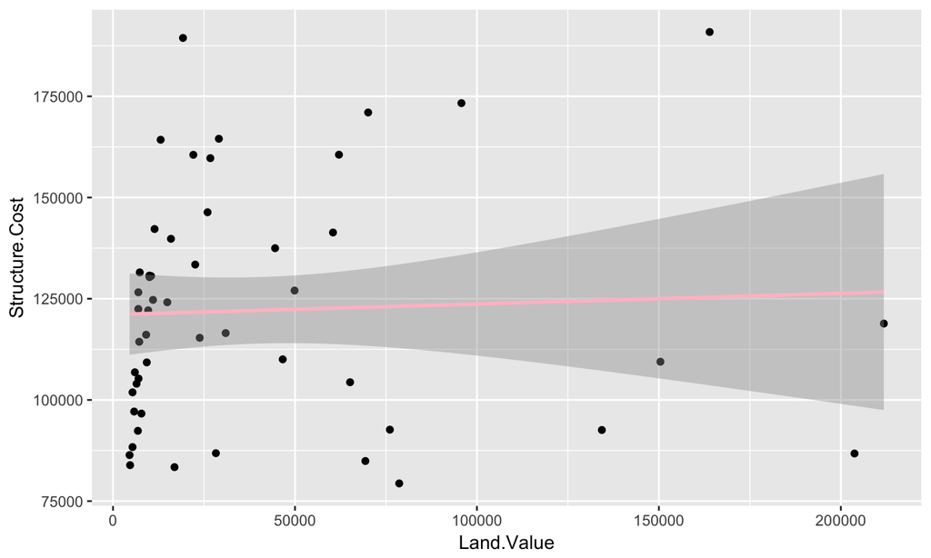

## That looks insane!

- let's log land value and see if it looks better

```r
ggplot(hp2001Q1, aes(x = log(Land.Value), y = Structure.Cost)) +
  geom_point() + stat_smooth(method = "lm", colour = "pink")
```

## try again

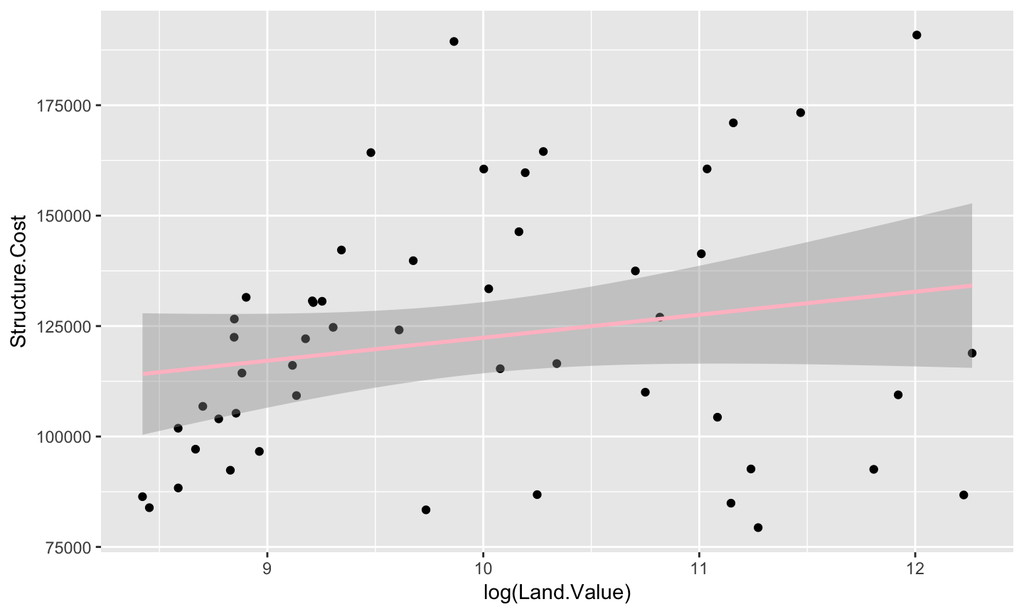

## Another example: Coefficient Plot

```r
mod1 <- lm(Structure.Cost ~ log(Land.Value) + Home.Price.Index, data = housing)
coef_plot_data <- data.table::data.table(var = names(mod1$coefficients),
  coef = mod1$coefficients,
  lower = mod1$coefficients - abs(qnorm(0.025) * sqrt(diag(vcov(mod1)))),
  upper = mod1$coefficients + abs(qnorm(0.025) * sqrt(diag(vcov(mod1)))))
coef_p <- ggplot(coef_plot_data, aes(x = var, y = coef)) + geom_point() +
  geom_errorbar(aes(ymin = lower, ymax = upper))
```

## Here's the coefficient plot

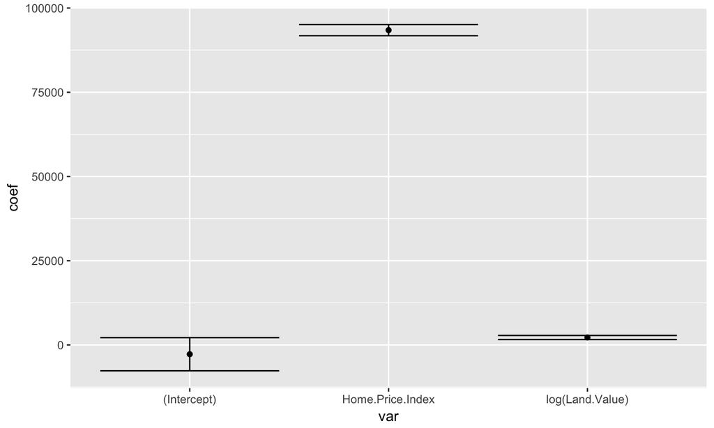

## Smoothers

- Things aren't always linear
- We can add smoothers to our plots
- What is a smoother?

## Smoother Example

```r
ggplot(hp2001Q1, aes(x = log(Land.Value), y = Structure.Cost)) +
  geom_point() + geom_smooth(method = "loess")
```

## Smoother Example

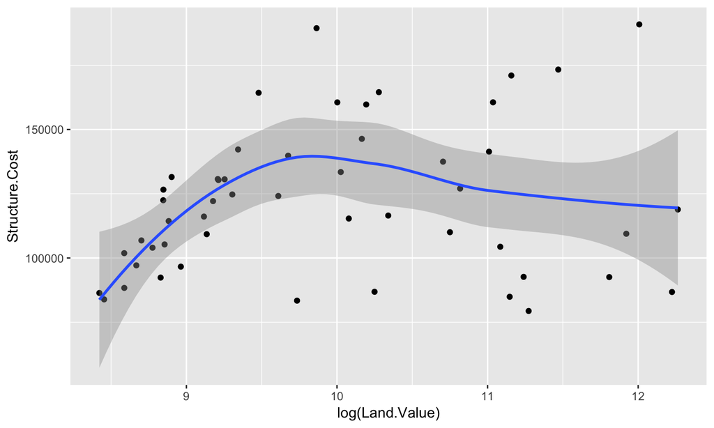

## Faceting

- Sometimes we want to plot separate graphs for subsets of data
- ggplot lets us do this with either facet_grid or facet_wrap
- Let's us easily compare plots

## Example

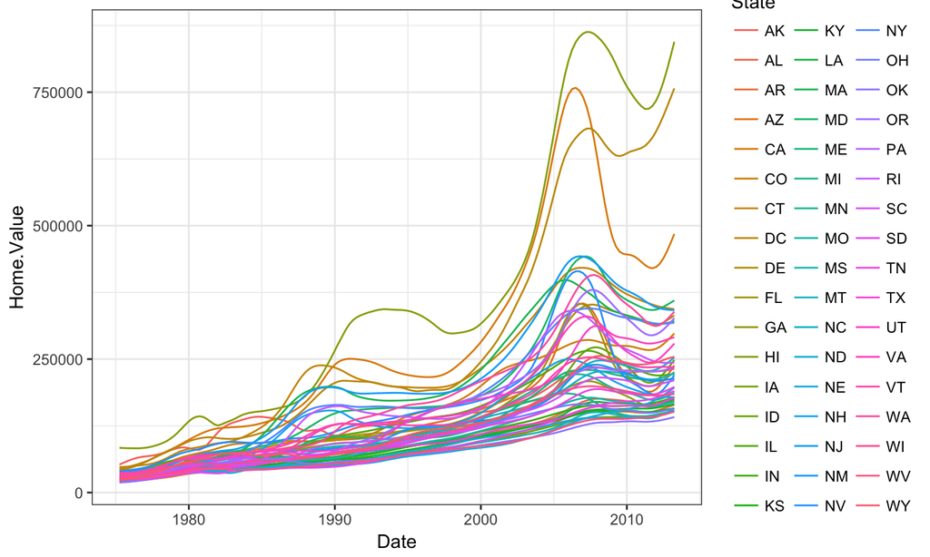

## This plot is horrible

- Why is it horrible?
- How can we fix it?
- Facet wrap or Facet grid!
- Facet wrap defines subsets as levels of a single grouping variable (state)
- Facet grid does the same but for two grouping variables

## Here's how we make it meaningful

```r
p5 <- ggplot(housing, aes(x = Date, y = Home.Value))
p6 <- p5 + geom_line() + theme_bw() +
  facet_wrap(~State, ncol = 10)
```

## What it looks like

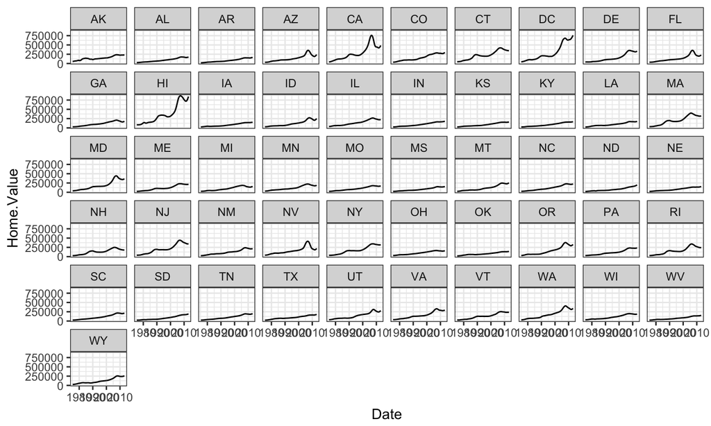

## Theme Dark

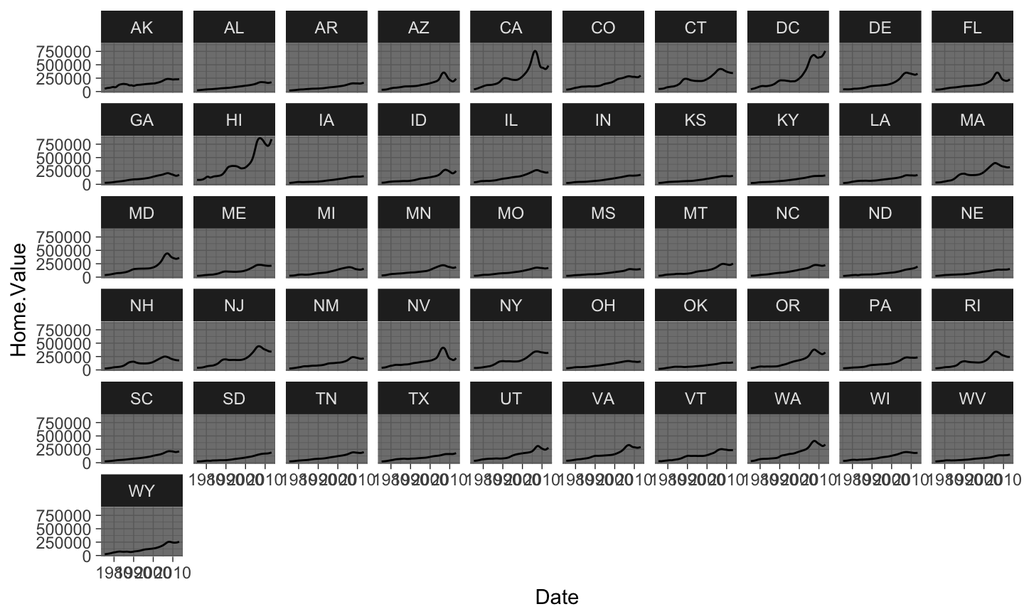

## Theme Lined Raw

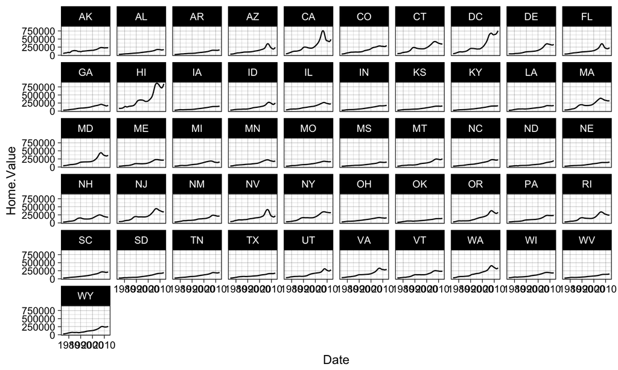

## Theme Minimal

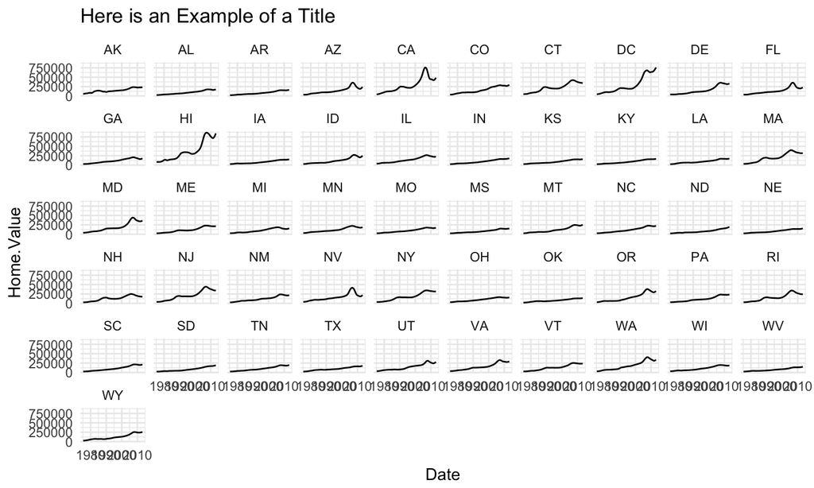